# Alejandre_Valeria_T3_P2

Alejandre Sanjuán Carla Valeria

22/3/2022

## Red booleana

Genera una red de regulación transripcional con 5 nodos y, al menos, 7 interacciones regulatorias, escoge al menos 3 inhibiciones).

1. Escribe las tablas de verdad de las reglas

Las tablas de verdad serian asi, considerando que mis genes seran denominados como A,B,C,D,E.

targets(ABC), factorS (REGLA)

A, B AND NOT C = A, B & !C B, B AND NOT E = B, B & !E C, A OR F AND NOT D = C, A | E &!D D, C E, D

Tenemos que cargar BoolNet para comenzar a trabajar con nuestras tablas de verdad

```r
library(BoolNet)
```

2. Escribe las reglas para generar una red de tipo Boolnet. Lo hice en un formato de texto plano y luego cargamos el archivo usando loadNetwork

```r
red_1 <- loadNetwork("red tarea.txt")
red_1
```

```
## Boolean network with 5 genes
##
## Involved genes:
## A B C D E
##
## Transition functions:
## A = B & ! C
## B = B & ! E
## C = A | E &! D
## D = C
## E = D
```

**Para visualizar mejor la red podemos plotearla con plotNetworkWiring,

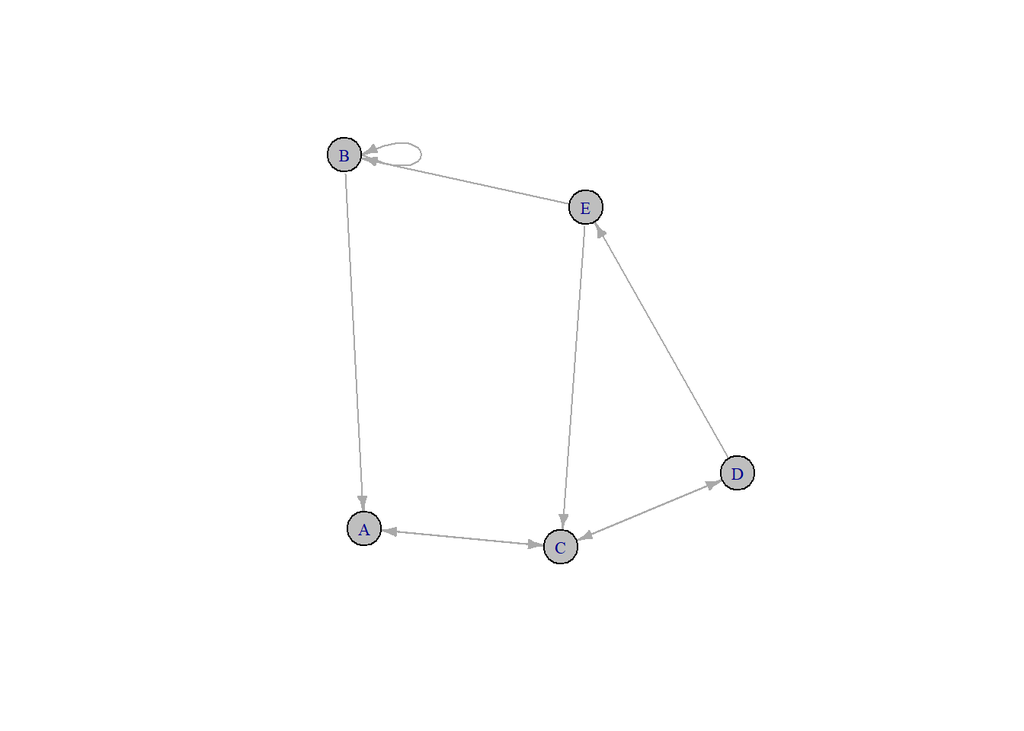

```r
plotNetworkWiring(red_1)
```

c) Encuentra todos los atractores de tu red, esto lo podemos hacer ya que tenemos la red cargada

```r
atrac_1 <- getAttractors(red_1)

atrac_1
```

```
## Attractor 1 is a simple attractor consisting of 1 state(s) and has a basin of 1 state(s):
##
##  |--<----|
##  V       |
##  00000   |
##  V       |
##  |-->----|
##
##
## Genes are encoded in the following order: A B C D E
##
## Attractor 2 is a simple attractor consisting of 3 state(s) and has a basin of 31 state(s):
##
##  |--<----|
##  V       |
##  00100   |
##  00010   |
##  00001   |
##  V       |
##  |-->----|
##
##
## Genes are encoded in the following order: A B C D E
```

Encontramos dos atractores: El primero es un atractor simple que tiene solo 1 estado, osea que es puntual, todos se encuentrana apagados (A,B,C,D,E)- El segundo atractor tambien es simple y tiene 3 estados donde justo estan marcados las 3 interacciones ihibitorias en dicho estado sucesivamente.

###d) ¿Cúal ser ́ıa el estado final más probable? Utilizando la tabla de transición de los estados podemos ver cuales seran los estados finales y ver cual es el estado final más probable

```r
getTransitionTable(atrac_1)
```

```
##   State     Next state  Attr. basin  # trans. to attr.
##   00000 =>       00000            1                  0
##   10000 =>       00100            2                  1
##   01000 =>       11000            2                  6
##   11000 =>       11100            2                  5
##   00100 =>       00010            2                  0
##   10100 =>       00110            2                  3
##   01100 =>       01010            2                  6
##   11100 =>       01110            2                  4
##   00010 =>       00001            2                  0
##   10010 =>       00101            2                  4
##   01010 =>       11001            2                  5
##   11010 =>       11101            2                  4
##   00110 =>       00011            2                  2
##   10110 =>       00111            2                  3
```

[output cut: 20 more lines]

Es más probable que esten apagos todos mientras que C,D,E con acción inhibidora estan encendidos y menos probable que todos esten apagados.

5. Dibuja todos los estados y sus atractores

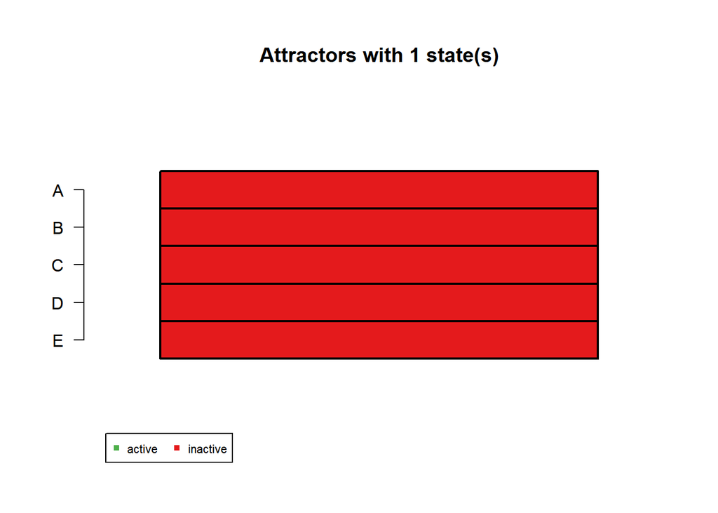

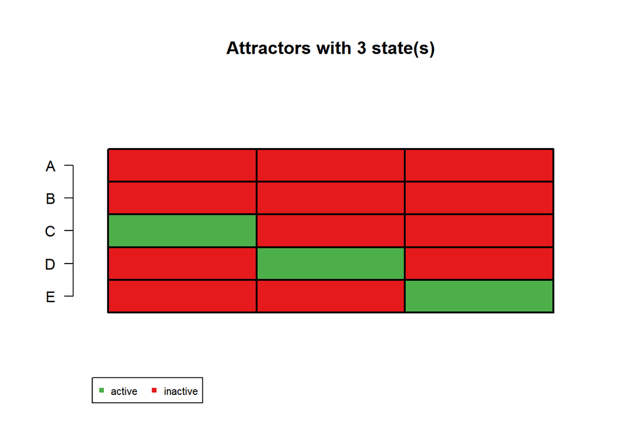

```
## $`1`
##   Attr1.1
## A       0
## B       0
## C       0
## D       0
## E       0
##
## $`3`
##   Attr2.1 Attr2.2 Attr2.3
## A       0       0       0
## B       0       0       0
## C       1       0       0
## D       0       1       0
## E       0       0       1
```

```r
plotAttractors(atrac_1)
```

Al graficas los atractores vemos como en el primer atractor todos se van a encontrar apagados y en el segundo como C, D Y E van a tener una intermitencia sucesiva en su activación, es menos probable que esten todos apagados a que existan una alternancia en la activación de los genes.

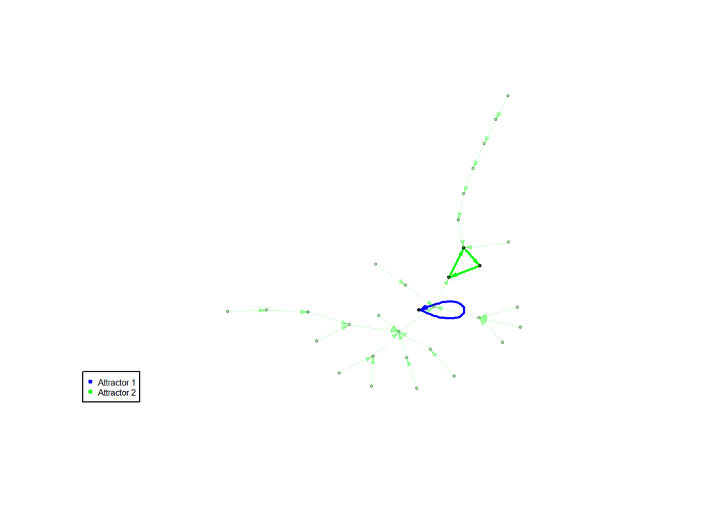

```r
plotStateGraph(atrac_1)
```